# CVTDM Project - Wine Quality

Sam Blum and Mathis Da Silva

25/11/2021

```r
rm(list = ls())

library(naniar)
library(ggplot2)
library(reshape2)
library(magrittr)
library(dplyr)
library(car)
library(GGally)
library(viridis)
library(caret)
library(ggplot2)
library(cowplot)
library(FNN)
library(MASS)
library(rpart)
library(rpart.plot)
library(adabag)
library(randomForest)
library(imbalance)
library(e1071)
library(neuralnet)
library(nnet)

# setwd("~/GitHub/CVTDM_Project")
wine = read.csv(file = "winequality-white.csv", header = T, sep = ";")
```

# Data Exploratory Analysis

## First Insights

First, let’s have a look at the variables and their types:

```r
str(wine)
```

```
## 'data.frame':    4898 obs. of  12 variables:
##  $ fixed.acidity       : num  7 6.3 8.1 7.2 7.2 8.1 6.2 7 6.3 8.1 ...
##  $ volatile.acidity    : num  0.27 0.3 0.28 0.23 0.23 0.28 0.32 0.27 0.3 0.22 ...
##  $ citric.acid         : num  0.36 0.34 0.4 0.32 0.32 0.4 0.16 0.36 0.34 0.43 ...
##  $ residual.sugar      : num  20.7 1.6 6.9 8.5 8.5 6.9 7 20.7 1.6 1.5 ...
##  $ chlorides           : num  0.045 0.049 0.05 0.058 0.058 0.05 0.045 0.045 0.049 0.044 ...
##  $ free.sulfur.dioxide : num  45 14 30 47 47 30 30 45 14 28 ...
##  $ total.sulfur.dioxide: num  170 132 97 186 186 97 136 170 132 129 ...
##  $ density             : num  1.001 0.994 0.995 0.996 0.996 ...
##  $ pH                  : num  3 3.3 3.26 3.19 3.19 3.26 3.18 3 3.3 3.22 ...
##  $ sulphates           : num  0.45 0.49 0.44 0.4 0.4 0.44 0.47 0.45 0.49 0.45 ...
##  $ alcohol             : num  8.8 9.5 10.1 9.9 9.9 10.1 9.6 8.8 9.5 11 ...
##  $ quality             : int  6 6 6 6 6 6 6 6 6 6 ...
```

Now, let’s create a *binned_quality* variable for the purpose of the problem:

```r
sapply(wine, function(x) length(unique(x)))
```

```
##        fixed.acidity     volatile.acidity          citric.acid
##                   68                  125                   87
##       residual.sugar            chlorides  free.sulfur.dioxide
##                  310                  160                  132
## total.sulfur.dioxide              density                   pH
##                  251                  890                  103
##            sulphates              alcohol              quality
##                   79                  103                    7
```

```r
wine$binned_quality = as.factor(ifelse(wine$quality < 5, 'Low',
                                ifelse(wine$quality >= 5 & wine$quality < 7, "Intermediate",
                                ifelse(wine$quality >= 7, "High", "None"))))

wine$quality = as.factor(wine$quality)
```

We can also have a look at the summary statistics:

```r
summary(wine)
```

```
##  fixed.acidity    volatile.acidity  citric.acid     residual.sugar
##  Min.   : 3.800   Min.   :0.0800   Min.   :0.0000   Min.   : 0.600
##  1st Qu.: 6.300   1st Qu.:0.2100   1st Qu.:0.2700   1st Qu.: 1.700
##  Median : 6.800   Median :0.2600   Median :0.3200   Median : 5.200
##  Mean   : 6.855   Mean   :0.2782   Mean   :0.3342   Mean   : 6.391
##  3rd Qu.: 7.300   3rd Qu.:0.3200   3rd Qu.:0.3900   3rd Qu.: 9.900
##  Max.   :14.200   Max.   :1.1000   Max.   :1.6600   Max.   :65.800
##
##    chlorides       free.sulfur.dioxide total.sulfur.dioxide    density
##  Min.   :0.00900   Min.   :  2.00      Min.   :  9.0        Min.   :0.9871
##  1st Qu.:0.03600   1st Qu.: 23.00      1st Qu.:108.0        1st Qu.:0.9917
##  Median :0.04300   Median : 34.00      Median :134.0        Median :0.9937
##  Mean   :0.04577   Mean   : 35.31      Mean   :138.4        Mean   :0.9940
##  3rd Qu.:0.05000   3rd Qu.: 46.00      3rd Qu.:167.0        3rd Qu.:0.9961
##  Max.   :0.34600   Max.   :289.00      Max.   :440.0        Max.   :1.0390
##
##        pH          sulphates         alcohol      quality       binned_quality
##  Min.   :2.720   Min.   :0.2200   Min.   : 8.00   3:  20   High        :1060
##  1st Qu.:3.090   1st Qu.:0.4100   1st Qu.: 9.50   4: 163   Intermediate:3655
##  Median :3.180   Median :0.4700   Median :10.40   5:1457   Low         : 183
##  Mean   :3.188   Mean   :0.4898   Mean   :10.51   6:2198
##  3rd Qu.:3.280   3rd Qu.:0.5500   3rd Qu.:11.40   7: 880
##  Max.   :3.820   Max.   :1.0800   Max.   :14.20   8: 175
##                                                   9:   5
```

```r
sapply(wine[,-c(12,13)], sd)
```

```
##        fixed.acidity     volatile.acidity          citric.acid
##          0.843868228          0.100794548          0.121019804
##       residual.sugar            chlorides  free.sulfur.dioxide
##          5.072057784          0.021847968         17.007137325
## total.sulfur.dioxide              density                   pH
##         42.498064554          0.002990907          0.151000600
##            sulphates              alcohol
##          0.114125834          1.230620568
```

```r
str(wine)
```

```
## 'data.frame':    4898 obs. of  13 variables:
##  $ fixed.acidity       : num  7 6.3 8.1 7.2 7.2 8.1 6.2 7 6.3 8.1 ...
##  $ volatile.acidity    : num  0.27 0.3 0.28 0.23 0.23 0.28 0.32 0.27 0.3 0.22 ...
##  $ citric.acid         : num  0.36 0.34 0.4 0.32 0.32 0.4 0.16 0.36 0.34 0.43 ...
##  $ residual.sugar      : num  20.7 1.6 6.9 8.5 8.5 6.9 7 20.7 1.6 1.5 ...
##  $ chlorides           : num  0.045 0.049 0.05 0.058 0.058 0.05 0.045 0.045 0.049 0.044 ...
##  $ free.sulfur.dioxide : num  45 14 30 47 47 30 30 45 14 28 ...
##  $ total.sulfur.dioxide: num  170 132 97 186 186 97 136 170 132 129 ...
##  $ density             : num  1.001 0.994 0.995 0.996 0.996 ...
##  $ pH                  : num  3 3.3 3.26 3.19 3.19 3.26 3.18 3 3.3 3.22 ...
##  $ sulphates           : num  0.45 0.49 0.44 0.4 0.4 0.44 0.47 0.45 0.49 0.45 ...
##  $ alcohol             : num  8.8 9.5 10.1 9.9 9.9 10.1 9.6 8.8 9.5 11 ...
##  $ quality             : Factor w/ 7 levels "3","4","5","6",..: 4 4 4 4 4 4 4 4 4 4 ...
##  $ binned_quality      : Factor w/ 3 levels "High","Intermediate",..: 2 2 2 2 2 2 2 2 2 2 ...
```

## Visualisation & Distributions

Let’s look at the distribution of the variables based on the quality variable (not binned, on a 0-10 scale):

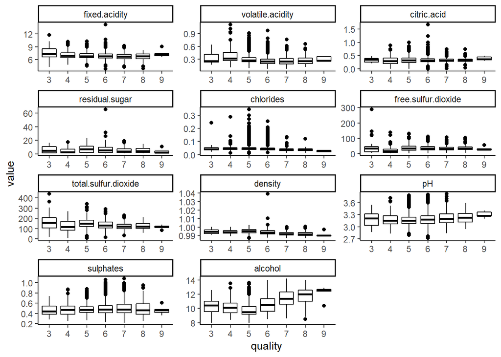

```r
boxplots = ggplot(data = melt(wine[,-13], "quality"), aes(quality, value, group = quality)) +
  geom_boxplot(fill = "transparent", color = "black") +
  facet_wrap(~variable, scale = "free", ncol = 3) +
  theme_classic()

boxplots
```

First, one can see that there are not a lot of variation between wine of different quality. There is a slight increase in alcohol quantity for wine of better quality, as well as a slight increase in pH levels.

Let’s continue by exploring the distribution of each variable:

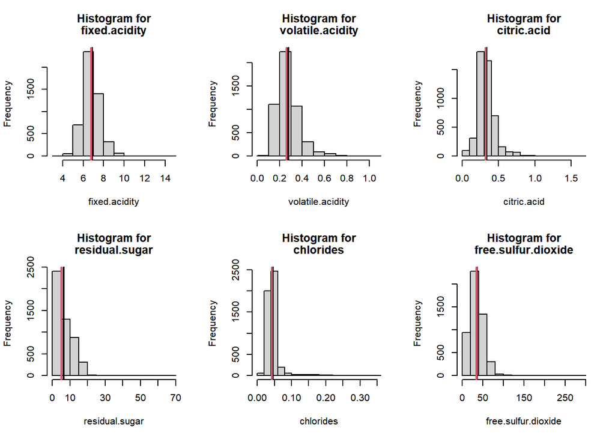

```r
par(mfrow=c(2, 3))
for (i in 1:11) {
  hist(wine[, i], main = c("Histogram for", names(wine[i])), xlab=names(wine[i]))
  abline(v = mean(wine[, i]), col = 1, lwd = 2)
  abline(v = median(wine[, i]), col = 2, lwd = 2)
}
```

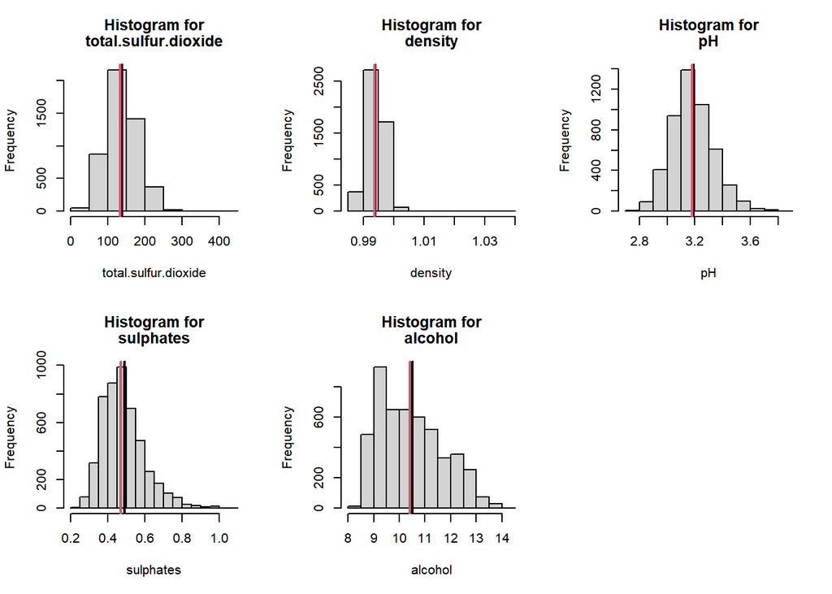

```r
par(mfrow=c(1, 1))
```

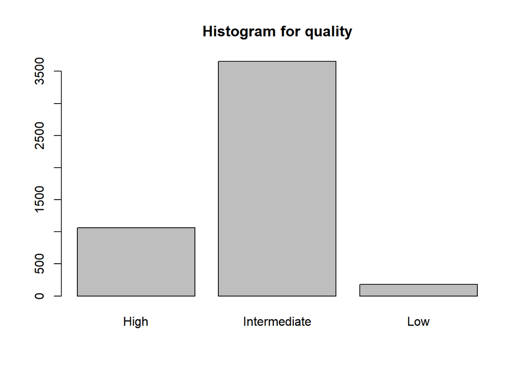

```r
barplot(table(wine$binned_quality), main = c("Histogram for quality", names(wine$binned_quality)), xlab=names(wine$binned_quality))
```

Our dataset faces two problems we have to deal with: imbalance between quality groups (‘Intermediate’ quality is over-represented) and skewness in the distribution of the explanatory variables.

To correct for the skewness, we can log-transform the variables of interest:

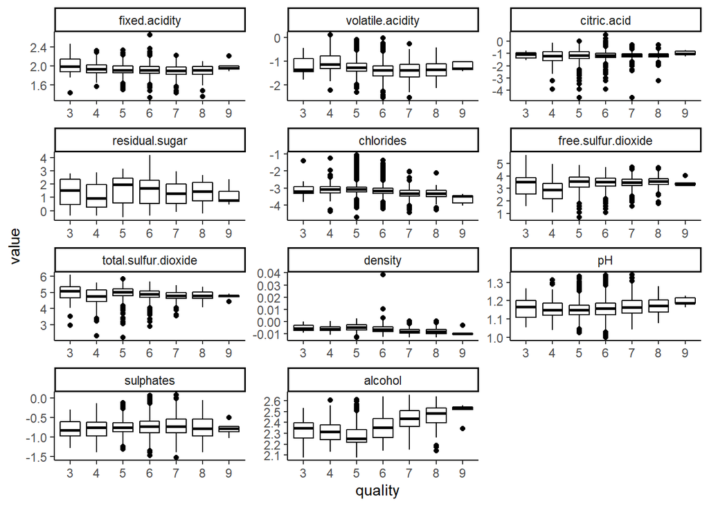

```r
alllogwine = wine
alllogwine[,-c(12,13)] = lapply(alllogwine[,-c(12,13)], log) #log transform all variables except quality and binned quality

boxplots = ggplot(data = melt(alllogwine[,-13], "quality"), aes(quality, value, group = quality)) +
  geom_boxplot(fill = "transparent", color = "black") +
  facet_wrap(~variable, scale = "free", ncol = 3) +
  theme_classic()

boxplots
```

Let’s have a look at the distribution of the variables after log-tranformation:

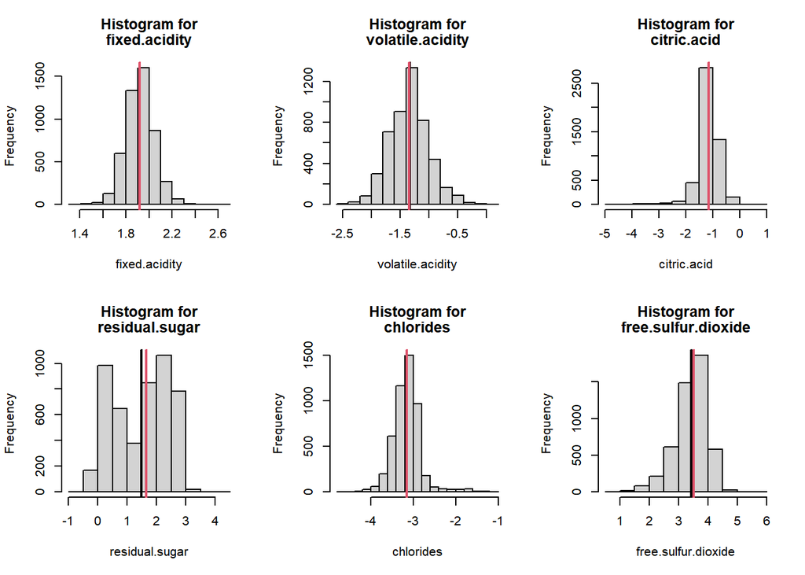

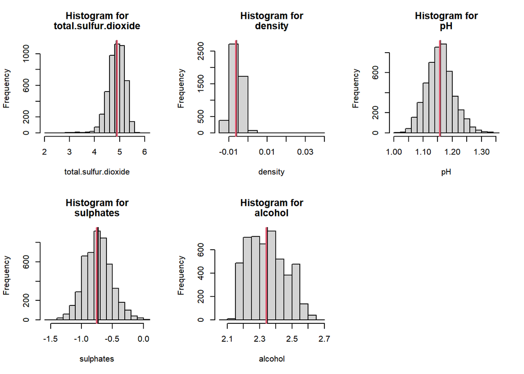

```r
par(mfrow=c(2, 3))
for (i in 1:11) {
  hist(alllogwine[, i], main = c("Histogram for", names(alllogwine[i])), xlab=names(alllogwine[i]))
  abline(v = mean(alllogwine[, i]), col = 1, lwd = 2)
  abline(v = median(alllogwine[, i]), col = 2, lwd = 2)
}
```

Clearly, we see an improvement in the distribution of the variables, with less variability due to extreme observations. There are still some variables for which the transformation does not add much: *citric.acid*, *total.sulfure.dioxide* and *pH*. Indeed, these variables were already pretty well distributed. Also, note that density is still right-skewed.

## Correlation Between Explanatory Variables

Now, let’s have a look at the correlation between the explanatory variables:

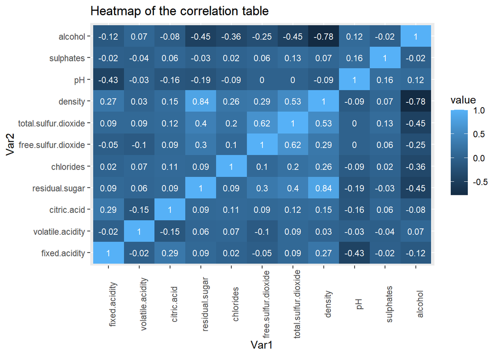

```r
cor_mat = round(cor(wine[,-c(12,13)]),2)
cor_mat2 = melt(cor_mat)

ggplot(data = cor_mat2, aes(x = Var1, y = Var2, fill = value)) +
  geom_tile() +
  geom_text(aes(Var2, Var1, label = value), color = "white", size = 3) +
  labs(title = "Heatmap of the correlation table") +
  theme(axis.text.x = element_text(angle=90))
```

We notice a high negative correlation coefficient between alcohol and density (-0.78). Because it is generally better to reduce the number of dimensions and because a high correlation might lead to multicollinearity issues, one can decide to drop the *density* variable.

Let’s look at the VIFs (Variance Inflation Factors) by performing a linear regression:

```r
wine$quality = as.numeric(wine$quality)

model = lm(quality ~., data = wine[,-13])
vif(model)
```

```
##        fixed.acidity     volatile.acidity          citric.acid
##             2.691435             1.141156             1.165215
##       residual.sugar            chlorides  free.sulfur.dioxide
##            12.644064             1.236822             1.787880
## total.sulfur.dioxide              density                   pH
##             2.239233            28.232546             2.196362
##            sulphates              alcohol
##             1.138540             7.706957
```

It appears that the *density* variable has a very high VIF (28.2) compared to other variables. Hence, let’s have a look at the model without *density* and see if there is an improvement:

```r
model2 = lm(quality ~., data = wine[,-c(8,13)])
vif(model2)
```

```
##        fixed.acidity     volatile.acidity          citric.acid
##             1.356128             1.128298             1.159884
##       residual.sugar            chlorides  free.sulfur.dioxide
##             1.435215             1.203645             1.744627
## total.sulfur.dioxide                   pH            sulphates
##             2.153170             1.330912             1.056637
##              alcohol
##             1.647117
```

```r
wine$quality = as.factor(wine$quality)
```

Clearly, the VIF of *alcohol* is lower compared to before (7.7 vs. 1.6). Thus, we will drop *density* from our models.

Finally, let’s look at this plot:

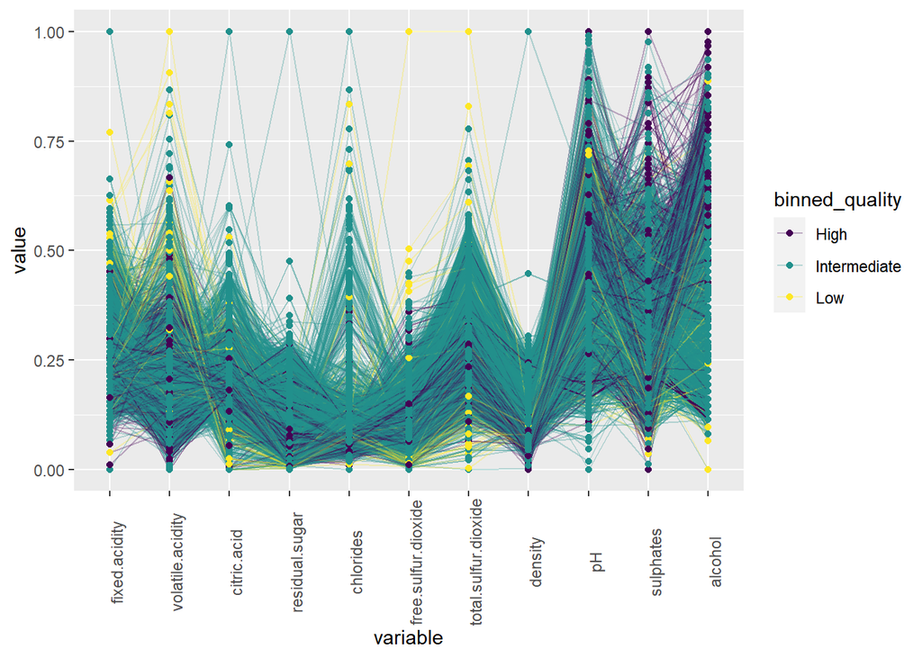

```r
ggparcoord(wine, columns = 1:11, groupColumn = 13, showPoints = TRUE, alphaLines = 0.3, scale = "uniminmax") + scale_color_viridis(discrete = TRUE) + theme(axis.text.x = element_text(angle = 90))
```

# Data pre-processing

## Variable selection and log-transformation

First, let’s drop density and quality:

```r
logwine = wine[,-c(8,12)]
```

Now, let’s log transform all variables except *citric.acid*, *total.sulfure.dioxide*, *pH* and *binned_quality*:

```r
logwine[,-c(3,7,8,11)] = lapply(logwine[,-c(3,7,8,11)], log) #log transform all variables except citric.acid, total.sulfure.dioxide, pH and binned_quality
head(logwine)
```

```
##   fixed.acidity volatile.acidity citric.acid residual.sugar chlorides
## 1      1.945910        -1.309333        0.36      3.0301337 -3.101093
## 2      1.840550        -1.203973        0.34      0.4700036 -3.015935
## 3      2.091864        -1.272966        0.40      1.9315214 -2.995732
## 4      1.974081        -1.469676        0.32      2.1400662 -2.847312
## 5      1.974081        -1.469676        0.32      2.1400662 -2.847312
## 6      2.091864        -1.272966        0.40      1.9315214 -2.995732
##   free.sulfur.dioxide total.sulfur.dioxide   pH  sulphates  alcohol
## 1            3.806662                  170 3.00 -0.7985077 2.174752
## 2            2.639057                  132 3.30 -0.7133499 2.251292
## 3            3.401197                   97 3.26 -0.8209806 2.312535
## 4            3.850148                  186 3.19 -0.9162907 2.292535
## 5            3.850148                  186 3.19 -0.9162907 2.292535
## 6            3.401197                   97 3.26 -0.8209806 2.312535
##   binned_quality
## 1   Intermediate
## 2   Intermediate
## 3   Intermediate
## 4   Intermediate
## 5   Intermediate
## 6   Intermediate
```

## Data partitioning

We can now proceed to the partitioning of the data, with a training set (50%), validation set (30%) and a test set (20%):

```r
set.seed(1)
train_index = createDataPartition(logwine$binned_quality, p = .5, list = FALSE)
train_df = logwine[train_index,]
valid_test_df = logwine[-train_index,]
valid_index = createDataPartition(valid_test_df$binned_quality, p = .6, list = FALSE)
valid_df = valid_test_df[valid_index,]
test_df = valid_test_df[-valid_index,]
```

## Data normalization

Because we use some classification techniques that require the data to be on a same scale (kNN, Neural Nets and Logistic Regression), we normalize the data on a [0,1] scale:

```r
#initialize normalized training and validation data frames to the original ones
train_norm_df = train_df
valid_norm_df = valid_df
test_norm_df = test_df

#use PreProcess() from the caret package and predict() to normalize numerical variables
norm_values = preProcess(train_df[,-c(11)], method = "range")
train_norm_df[,-c(11)] = predict(norm_values, train_df[,-c(11)])
valid_norm_df[,-c(11)] = predict(norm_values, valid_df[,-c(11)])
test_norm_df[,-c(11)] = predict(norm_values, test_df[,-c(11)])
```

## Dummyfication of the outcome variable

Because we perform multi-label classification, and because the *neuralnet* package requires the outcome variable to be coded as (0, 1) vector, we create 3 dummies, one for every quality level (‘High’, ‘Intermediate’ and ‘Low’). Note that we also apply this to validation and training sets:

```r
# Initialize normalized training and validation data frames with dummies to the normalized ones
train_norm_dummy_df <- train_norm_df
valid_norm_dummy_df <- valid_norm_df
test_norm_dummy_df <- test_norm_df

# Creation of the vectors and implementation
train_norm_dummy_df$high_quality <- ifelse(train_norm_dummy_df$binned_quality == "High", 1, 0)
train_norm_dummy_df$intermediate_quality <- ifelse(train_norm_dummy_df$binned_quality == "Intermediate", 1, 0)
train_norm_dummy_df$low_quality <- ifelse(train_norm_dummy_df$binned_quality == "Low", 1, 0)

valid_norm_dummy_df$high_quality <- ifelse(valid_norm_dummy_df$binned_quality == "High", 1, 0)
valid_norm_dummy_df$intermediate_quality <- ifelse(valid_norm_dummy_df$binned_quality == "Intermediate", 1, 0)
valid_norm_dummy_df$low_quality <- ifelse(valid_norm_dummy_df$binned_quality == "Low", 1, 0)

test_norm_dummy_df$high_quality <- ifelse(test_norm_dummy_df$binned_quality == "High", 1, 0)
test_norm_dummy_df$intermediate_quality <- ifelse(test_norm_dummy_df$binned_quality == "Intermediate", 1, 0)
test_norm_dummy_df$low_quality <- ifelse(test_norm_dummy_df$binned_quality == "Low", 1, 0)
```

## Oversampling

As stated earlier in the Data Exploratory Analysis, we face an imbalanced dataset:

```r
table(logwine$binned_quality)
```

```
##
##         High Intermediate          Low
##         1060         3655          183
```

```r
prop.table(table(logwine$binned_quality))
```

```
##
##         High Intermediate          Low
##   0.21641486   0.74622295   0.03736219
```

We see that ‘Intermediate’ quality represents 74.6% of observations, whereas ‘High’ and ‘Low’ quality only represent 21.6% and 3.7% of observations (respectively). Thus, the classification models could have problems in predicting ‘High’, and even more importantly ‘Low’ observations, as they only represent 3.7% of observations.

To solve this problem, we can oversample the ‘Low’ observations and add them into the training set. We use Random Walk Oversampling, as this method is known to be one of the most effective, especially when facing such an imbalanced dataset (Huaxiang Zhang, Mingfang Li, 2014).

Now, let’s create 1736 new instances for ‘Low’ and 1298 instances for ‘High’ quality (such that we have the same number of observations in each category within the training set) and let’s add them to the training set:

```r
set.seed(1)
add_low_train_df = rwo(train_df, 1736, "binned_quality") # Generation of 1736 instances for 'Low'
os_train_df = rbind(train_df, add_low_train_df) # Combining the new instances to the training set
set.seed(1)
add_high_train_df = rwo(os_train_df, 1298, "binned_quality") # Generation of 1298 instances for 'High'
os_train_df = rbind(os_train_df, add_high_train_df)
```

Let’s normalize the newly generated observations, and add them to the normalize training set:

```r
os_train_norm_df = os_train_df

#use PreProcess() from the caret package and predict() to normalize numerical variables
os_norm_values = preProcess(os_train_df[,-c(11)], method = "range")
os_train_norm_df[,-c(11)] = predict(os_norm_values, os_train_df[,-c(11)])
```

We can also add these newly generated observations to the normalized training set with dummies for quality (used for Neural Nets):

```r
# Initialize oversampled normalized training set with dummies to the oversampled normalized one
os_train_norm_dummy_df <- os_train_norm_df

os_train_norm_dummy_df$high_quality <- ifelse(os_train_norm_dummy_df$binned_quality == "High", 1, 0)
os_train_norm_dummy_df$intermediate_quality <- ifelse(os_train_norm_dummy_df$binned_quality == "Intermediate", 1, 0)
os_train_norm_dummy_df$low_quality <- ifelse(os_train_norm_dummy_df$binned_quality == "Low", 1, 0)
```

# Analysis

## kNN

Let’s proceed to the kNN:

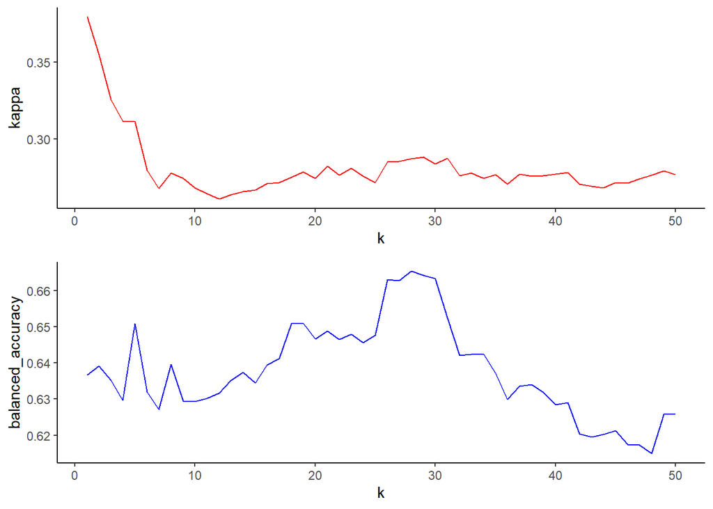

```r
#initialize a new data frame with three columns: k, kappa, and balanced_accuracy
best_k_df = data.frame(k = seq(1, 50, 1), kappa = rep(0,50), balanced_accuracy = rep(0,50))

#perform knn on the validation set using different k then store kappa and balanced accuracy for each k in the data frame
for(i in 1:50) {
  knn_pred = knn(train = os_train_norm_df[,-11], test = valid_norm_df[,-11], cl = os_train_norm_df[,11], k = i)
  best_k_df[i, 2] = confusionMatrix(knn_pred, valid_norm_df[,11])$overall[2]
  low_sensitivity = confusionMatrix(knn_pred, valid_norm_df[,11])$byClass[3,1]
  intermediate_sensitivity = confusionMatrix(knn_pred, valid_norm_df[,11])$byClass[2,1]
  high_sensitivity = confusionMatrix(knn_pred, valid_norm_df[,11])$byClass[1,1]
  best_k_df[i, 3] = (low_sensitivity + intermediate_sensitivity + high_sensitivity) / 3
}

kappa_plot = ggplot(data= best_k_df) + geom_line(aes(x=k,y=kappa), color="red") + theme_classic()
balanced_accuray_plot = ggplot(data= best_k_df) + geom_line(aes(x=k,y=balanced_accuracy), color="blue") + theme_classic()

plot_grid(kappa_plot, balanced_accuray_plot, ncol = 1, align = "v")
```

```r
which.max(best_k_df$kappa)#best k based on kappa
```

```
## [1] 1
```

```r
which.max(best_k_df$balanced_accuracy)#best k based on balanced accuracy
```

```
## [1] 28
```

Choosing this parameter(k=1), we can assess the predictive performance of the kNN model on the test set:

```r
#perform knn classification on the test set using best k = 1
set.seed(1)
best_knn_pred = knn3Train(train = os_train_norm_df[,-11], test = test_norm_df[,-11], cl = os_train_norm_df[,11], k = 1, prob = T)
best_knn_cm <- confusionMatrix(as.factor(best_knn_pred), test_norm_df[,11])#create corresponding confusion matrix
best_knn_cm
```

```
## Confusion Matrix and Statistics
##
##               Reference
## Prediction     High Intermediate Low
##   High          141          114   2
##   Intermediate   51          519  16
##   Low            20           97  18
##
## Overall Statistics
##
##                Accuracy : 0.6933
##                  95% CI : (0.6633, 0.722)
##     No Information Rate : 0.7464
##     P-Value [Acc > NIR] : 0.9999
##
##                   Kappa : 0.3749
##
##  Mcnemar's Test P-Value : <2e-16
##
## Statistics by Class:
##
##                      Class: High Class: Intermediate Class: Low
## Sensitivity               0.6651              0.7110    0.50000
## Specificity               0.8486              0.7298    0.87580
## Pos Pred Value            0.5486              0.8857    0.13333
## Neg Pred Value            0.9015              0.4617    0.97865
## Prevalence                0.2168              0.7464    0.03681
## Detection Rate            0.1442              0.5307    0.01840
## Detection Prevalence      0.2628              0.5992    0.13804
## Balanced Accuracy         0.7568              0.7204    0.68790
```

```r
kappa_best_knn = best_knn_cm$overall[2]
kappa_best_knn
```

```
##     Kappa
## 0.3748935
```

```r
low_sensitivity = best_knn_cm$byClass[3,1]
intermediate_sensitivity = best_knn_cm$byClass[2,1]
high_sensitivity = best_knn_cm$byClass[1,1]

bal_acc_best_knn = (low_sensitivity + intermediate_sensitivity + high_sensitivity) / 3
bal_acc_best_knn
```

```
## [1] 0.6253511
```

## Logistic regression

```r
os_log_reg = multinom(binned_quality ~ ., data = os_train_df)
summary(os_log_reg)
```

```
## Call:
## multinom(formula = binned_quality ~ ., data = os_train_df)
##
## Coefficients:
##              (Intercept) fixed.acidity volatile.acidity citric.acid
## Intermediate    31.86889     -0.962256         1.332421    1.997239
## Low             41.98841      1.637545         3.410483    2.390439
##              residual.sugar chlorides free.sulfur.dioxide total.sulfur.dioxide
## Intermediate     -0.2389481  1.275859          -0.4741764         0.0001637821
## Low              -0.4902087  1.084144          -2.0908903         0.0007713492
##                      pH   sulphates    alcohol
## Intermediate -0.9102455 -0.49837427  -8.518968
## Low           0.3831240  0.04088377 -13.564077
##
## Std. Errors:
##              (Intercept) fixed.acidity volatile.acidity citric.acid
## Intermediate  0.03791899     0.2653690        0.1202564   0.3810659
## Low           0.05520153     0.3293996        0.1469022   0.4245366
##              residual.sugar chlorides free.sulfur.dioxide total.sulfur.dioxide
## Intermediate     0.04616474 0.1677127          0.07507555         0.0002866020
## Low              0.05390061 0.1941242          0.08257761         0.0002893369
##                     pH sulphates   alcohol
## Intermediate 0.1995491 0.1552705 0.3660252
## Low          0.2476004 0.1893426 0.4563050
##
## Residual Deviance: 8575.034
## AIC: 8619.034
```

```r
os_log_prob = predict(os_log_reg, newdata = test_df, type = "p")

os_log_pred = data.frame("pred" = colnames(os_log_prob)[apply(os_log_prob,1,which.max)])
os_log_pred$pred = as.factor(os_log_pred$pred)

os_log_cm <- confusionMatrix(os_log_pred$pred, test_df[,11])
os_log_cm
```

```
## Confusion Matrix and Statistics
##
##               Reference
## Prediction     High Intermediate Low
##   High          158          217   2
##   Intermediate   41          363   8
##   Low            13          150  26
##
## Overall Statistics
##
##                Accuracy : 0.5593
##                  95% CI : (0.5275, 0.5907)
##     No Information Rate : 0.7464
##     P-Value [Acc > NIR] : 1
##
##                   Kappa : 0.2592
##
##  Mcnemar's Test P-Value : <2e-16
##
## Statistics by Class:
##
##                      Class: High Class: Intermediate Class: Low
## Sensitivity               0.7453              0.4973    0.72222
## Specificity               0.7141              0.8024    0.82696
## Pos Pred Value            0.4191              0.8811    0.13757
## Neg Pred Value            0.9101              0.3516    0.98733
## Prevalence                0.2168              0.7464    0.03681
## Detection Rate            0.1616              0.3712    0.02658
## Detection Prevalence      0.3855              0.4213    0.19325
## Balanced Accuracy         0.7297              0.6498    0.77459
```

```r
kappa_logist = os_log_cm$overall[2]
kappa_logist
```

```
##     Kappa
## 0.2591899
```

```r
low_sensitivity = os_log_cm$byClass[3,1]
intermediate_sensitivity = os_log_cm$byClass[2,1]
high_sensitivity = os_log_cm$byClass[1,1]

bal_acc_logist = (low_sensitivity + intermediate_sensitivity + high_sensitivity) / 3
bal_acc_logist
```

```
## [1] 0.6549218
```

## Naive Bayes

```r
os_nb_model = naiveBayes (binned_quality ~ ., data = os_train_df)
os_nb_model
```

```
##
## Naive Bayes Classifier for Discrete Predictors
##
## Call:
## naiveBayes.default(x = X, y = Y, laplace = laplace)
##
## A-priori probabilities:
## Y
##         High Intermediate          Low
##    0.3333333    0.3333333    0.3333333
##
## Conditional probabilities:
##               fixed.acidity
## Y                  [,1]      [,2]
##   High         1.901409 0.1148070
##   Intermediate 1.918476 0.1220817
##   Low          1.949177 0.1528686
##
##               volatile.acidity
## Y                   [,1]      [,2]
##   High         -1.390723 0.3460800
##   Intermediate -1.339210 0.3204440
##   Low          -1.061166 0.3876045
##
##               citric.acid
## Y                   [,1]      [,2]
##   High         0.3245435 0.0778726
##   Intermediate 0.3371007 0.1261949
##   Low          0.3079582 0.1617614
##
##               residual.sugar
## Y                  [,1]      [,2]
##   High         1.337543 0.8285368
##   Intermediate 1.549765 0.9327049
##   Low          1.106317 0.9428895
##
##               chlorides
## Y                   [,1]      [,2]
##   High         -3.300988 0.2666303
##   Intermediate -3.108617 0.3105590
```

[output cut: 16 more lines]

```
##   High         3.211628 0.1553305
##   Intermediate 3.183485 0.1485863
##   Low          3.191302 0.1664048
##
##               sulphates
## Y                    [,1]      [,2]
##   High         -0.7166881 0.2587124
##   Intermediate -0.7382040 0.2114988
##   Low          -0.7587270 0.2463432
##
##               alcohol
## Y                  [,1]       [,2]
##   High         2.426630 0.11687083
##   Intermediate 2.325167 0.10633337
##   Low          2.322142 0.09880537
```

```r
os_nb_pred = predict(os_nb_model, newdata = test_df, type = "class")
os_nb_prob = predict(os_nb_model, newdata = test_df, type = "raw")
bayes_cm <- confusionMatrix(os_nb_pred, test_df[,11])
bayes_cm
```

```
## Confusion Matrix and Statistics
##
##               Reference
## Prediction     High Intermediate Low
##   High          163          231   4
##   Intermediate   46          433  13
##   Low             3           66  19
##
## Overall Statistics
##
##                Accuracy : 0.6288
##                  95% CI : (0.5977, 0.6592)
##     No Information Rate : 0.7464
##     P-Value [Acc > NIR] : 1
##
##                   Kappa : 0.3036
##
##  Mcnemar's Test P-Value : <2e-16
##
## Statistics by Class:
##
##                      Class: High Class: Intermediate Class: Low
## Sensitivity               0.7689              0.5932    0.52778
## Specificity               0.6932              0.7621    0.92675
## Pos Pred Value            0.4095              0.8801    0.21591
## Neg Pred Value            0.9155              0.3889    0.98090
## Prevalence                0.2168              0.7464    0.03681
## Detection Rate            0.1667              0.4427    0.01943
## Detection Prevalence      0.4070              0.5031    0.08998
## Balanced Accuracy         0.7310              0.6776    0.72726
```

```r
kappa_bayes = bayes_cm$overall[2]
kappa_bayes
```

```
##     Kappa
## 0.3035937
```

```r
low_sensitivity = bayes_cm$byClass[3,1]
intermediate_sensitivity = bayes_cm$byClass[2,1]
high_sensitivity = bayes_cm$byClass[1,1]

bal_acc_bayes = (low_sensitivity + intermediate_sensitivity + high_sensitivity) / 3
bal_acc_bayes
```

```
## [1] 0.6299321
```

## Classification trees

### Regular Classification Tree

Let’s first create a fully grown tree before pruning it to the best CP (i.e., CP associated with the minimum standard error):

```r
set.seed(1)
tree1 <- rpart(binned_quality ~ ., data=os_train_df, method = "class", control = rpart.control(cp = 0, minbucket = 2, xval = 5))

# Look at the minimum standard error
printcp(tree1)
```

```
##
## Classification tree:
## rpart(formula = binned_quality ~ ., data = os_train_df, method = "class",
##     control = rpart.control(cp = 0, minbucket = 2, xval = 5))
##
## Variables actually used in tree construction:
##  [1] alcohol              chlorides            citric.acid
##  [4] fixed.acidity        free.sulfur.dioxide  pH
##  [7] residual.sugar       sulphates            total.sulfur.dioxide
## [10] volatile.acidity
##
## Root node error: 3656/5484 = 0.66667
##
## n= 5484
##
```

[output cut: 41 more lines]

```r
which.min(tree1$cptable[, 4])
```

```
## 38
## 38
```

```r
# Take the cp associated with the minimum standard error to prune the tree:
set.seed(1)
pruned_tree1 <- prune(tree1, cp = tree1$cptable[which.min(tree1$cptable[, "xerror"]), "CP"])

# If we want to look at the most important variables:
pruned_tree1$variable.importance
```

```
## total.sulfur.dioxide              alcohol  free.sulfur.dioxide
##            1294.0463             697.9393             648.7481
##            chlorides     volatile.acidity       residual.sugar
##             536.7401             512.5792             483.5053
##                   pH            sulphates          citric.acid
##             437.1729             431.2653             424.1669
##        fixed.acidity
##             377.5757
```

```r
# We can now predict the outcome:
pruned_tree1_pred_test <- predict(pruned_tree1, test_df, type="class")
pruned_tree1_prob_test <- predict(pruned_tree1, test_df, type="prob")
pruned_tree1_cm <- confusionMatrix(pruned_tree1_pred_test, test_df$binned_quality)
pruned_tree1_cm
```

```
## Confusion Matrix and Statistics
##
##               Reference
## Prediction     High Intermediate Low
##   High          124          114   0
##   Intermediate   83          568  24
##   Low             5           48  12
##
## Overall Statistics
##
##                Accuracy : 0.7198
##                  95% CI : (0.6905, 0.7478)
##     No Information Rate : 0.7464
##     P-Value [Acc > NIR] : 0.973312
##
##                   Kappa : 0.3479
##
##  Mcnemar's Test P-Value : 0.000466
##
## Statistics by Class:
##
##                      Class: High Class: Intermediate Class: Low
## Sensitivity               0.5849              0.7781    0.33333
## Specificity               0.8512              0.5685    0.94374
## Pos Pred Value            0.5210              0.8415    0.18462
## Neg Pred Value            0.8811              0.4653    0.97371
## Prevalence                0.2168              0.7464    0.03681
## Detection Rate            0.1268              0.5808    0.01227
## Detection Prevalence      0.2434              0.6902    0.06646
## Balanced Accuracy         0.7180              0.6733    0.63854
```

```r
kappa_pruned_tree1 = pruned_tree1_cm$overall[2]
kappa_pruned_tree1
```

```
##     Kappa
## 0.3479016
```

```r
low_sensitivity = pruned_tree1_cm$byClass[3,1]
intermediate_sensitivity = pruned_tree1_cm$byClass[2,1]
high_sensitivity = pruned_tree1_cm$byClass[1,1]
bal_acc_pruned_tree1 = (low_sensitivity + intermediate_sensitivity + high_sensitivity) / 3
bal_acc_pruned_tree1
```

```
## [1] 0.5654404
```

### Boosted tree

Let’s proceed to the Boosted Tree:

```r
set.seed(1)
boost1 <- boosting(binned_quality ~ ., data=os_train_df, control = rpart.control(xval = 5))
boost1_pred_test <- predict(boost1, test_df, type="class")
boost1_prob_test <- predict(boost1, test_df, type="prob")
boost1_cm <- confusionMatrix(as.factor(boost1_pred_test$class), test_df$binned_quality)
boost1_cm
```

```
## Confusion Matrix and Statistics
##
##               Reference
## Prediction     High Intermediate Low
##   High          158          195   3
##   Intermediate   51          495  18
##   Low             3           40  15
##
## Overall Statistics
##
##                Accuracy : 0.683
##                  95% CI : (0.6528, 0.7121)
##     No Information Rate : 0.7464
##     P-Value [Acc > NIR] : 1
##
##                   Kappa : 0.3511
##
##  Mcnemar's Test P-Value : <2e-16
##
## Statistics by Class:
##
##                      Class: High Class: Intermediate Class: Low
## Sensitivity               0.7453              0.6781    0.41667
## Specificity               0.7415              0.7218    0.95435
## Pos Pred Value            0.4438              0.8777    0.25862
## Neg Pred Value            0.9132              0.4324    0.97717
## Prevalence                0.2168              0.7464    0.03681
## Detection Rate            0.1616              0.5061    0.01534
## Detection Prevalence      0.3640              0.5767    0.05930
## Balanced Accuracy         0.7434              0.6999    0.68551
```

```r
kappa_boost1 = boost1_cm$overall[2]
kappa_boost1
```

```
##     Kappa
## 0.3510758
```

```r
low_sensitivity = boost1_cm$byClass[3,1]
intermediate_sensitivity = boost1_cm$byClass[2,1]
high_sensitivity = boost1_cm$byClass[1,1]
bal_acc_boost1 = (low_sensitivity + intermediate_sensitivity + high_sensitivity) / 3
bal_acc_boost1
```

```
## [1] 0.613344
```

### Bagged tree

Let’s proceed to the Bagged Tree:

```r
set.seed(1)
bag1 <- bagging(binned_quality ~ ., data=os_train_df, control = rpart.control(xval = 5))
bag1_pred_test <- predict(bag1, test_df, type="class")
bag1_prob_test <- predict(bag1, test_df, type="prob")
bag1_cm <- confusionMatrix(as.factor(bag1_pred_test$class), test_df$binned_quality)
bag1_cm
```

```
## Confusion Matrix and Statistics
##
##               Reference
## Prediction     High Intermediate Low
##   High          170          228   5
##   Intermediate   40          456  18
##   Low             2           46  13
##
## Overall Statistics
##
##                Accuracy : 0.6534
##                  95% CI : (0.6226, 0.6832)
##     No Information Rate : 0.7464
##     P-Value [Acc > NIR] : 1
##
##                   Kappa : 0.3284
##
##  Mcnemar's Test P-Value : <2e-16
##
## Statistics by Class:
##
##                      Class: High Class: Intermediate Class: Low
## Sensitivity               0.8019              0.6247    0.36111
## Specificity               0.6958              0.7661    0.94904
## Pos Pred Value            0.4218              0.8872    0.21311
## Neg Pred Value            0.9270              0.4095    0.97492
## Prevalence                0.2168              0.7464    0.03681
## Detection Rate            0.1738              0.4663    0.01329
## Detection Prevalence      0.4121              0.5256    0.06237
## Balanced Accuracy         0.7489              0.6954    0.65508
```

```r
kappa_bag1 = bag1_cm$overall[2]
kappa_bag1
```

```
##    Kappa
## 0.328362
```

```r
low_sensitivity = bag1_cm$byClass[3,1]
intermediate_sensitivity = bag1_cm$byClass[2,1]
high_sensitivity = bag1_cm$byClass[1,1]
bal_acc_bag1 = (low_sensitivity + intermediate_sensitivity + high_sensitivity) / 3
bal_acc_bag1
```

```
## [1] 0.5958851
```

### Random Forest

Let’s proceed to the Random Forest:

```r
set.seed(1)
rf1 <- randomForest(os_train_df[-11], os_train_df$binned_quality, control = rpart.control(xval = 5))
rf1_pred_test <- predict(rf1, test_df, type="class")
rf1_prob_test <- predict(rf1, test_df, type="prob")
rf1_cm <- confusionMatrix(rf1_pred_test, test_df$binned_quality)
rf1_cm
```

```
## Confusion Matrix and Statistics
##
##               Reference
## Prediction     High Intermediate Low
##   High          138           79   0
##   Intermediate   73          639  26
##   Low             1           12  10
##
## Overall Statistics
##
##                Accuracy : 0.8047
##                  95% CI : (0.7784, 0.8291)
##     No Information Rate : 0.7464
##     P-Value [Acc > NIR] : 1.001e-05
##
##                   Kappa : 0.4964
##
##  Mcnemar's Test P-Value : 0.09391
##
## Statistics by Class:
##
##                      Class: High Class: Intermediate Class: Low
## Sensitivity               0.6509              0.8753    0.27778
## Specificity               0.8969              0.6008    0.98620
## Pos Pred Value            0.6359              0.8659    0.43478
## Neg Pred Value            0.9028              0.6208    0.97277
## Prevalence                0.2168              0.7464    0.03681
## Detection Rate            0.1411              0.6534    0.01022
## Detection Prevalence      0.2219              0.7546    0.02352
## Balanced Accuracy         0.7739              0.7381    0.63199
```

```r
kappa_rf1 = rf1_cm$overall[2]
kappa_rf1
```

```
##     Kappa
## 0.4963819
```

```r
low_sensitivity = rf1_cm$byClass[3,1]
intermediate_sensitivity = rf1_cm$byClass[2,1]
high_sensitivity = rf1_cm$byClass[1,1]
bal_acc_rf1 = (low_sensitivity + intermediate_sensitivity + high_sensitivity) / 3
bal_acc_rf1
```

```
## [1] 0.6013545
```

## Neural Nets

### Determination of the best Neural Net with a threshold of 0.5

```r
nn_nodes_1 <- data.frame("number_nodes" = seq(from= 2, to = 10), "kappa_value" = NA, "balanced_accuracy" = NA)

for (i in 2:10){
  set.seed(1)
  nn <- neuralnet(high_quality + intermediate_quality + low_quality ~ ., data = os_train_norm_dummy_df[, -11], hidden = i, linear.output = FALSE, threshold = 0.5)
  valid_pred_nn <- data.frame(predict(nn, valid_norm_dummy_df[, -c(11, 12, 13, 14)]))
  names(valid_pred_nn)[1:3] <- c("High", "Intermediate", "Low")
  valid_pred_nn$Prediction <- NA

  for(j in 1:length(valid_pred_nn$High)) {
  valid_pred_nn[j, 4] <- names(which.max(valid_pred_nn[j, 1:3]))
}

  nn.cm <- confusionMatrix(as.factor(valid_pred_nn$Prediction),valid_norm_df$binned_quality)
  nn_nodes_1[i-1, 2] <- nn.cm[["overall"]][["Kappa"]]
  nn_nodes_1[i-1, 3] <- (nn.cm$byClass[3,1] + nn.cm$byClass[2,1] + nn.cm$byClass[1,1]) / 3
}

nn_nodes_1
```

```
##   number_nodes kappa_value balanced_accuracy
## 1            2  0.26520018         0.6130463
## 2            3  0.27326774         0.6208693
## 3            4  0.27504687         0.6223886
## 4            5  0.04396906         0.3871228
## 5            6  0.03760601         0.3682718
## 6            7  0.05115352         0.3827653
## 7            8  0.29838043         0.6199154
## 8            9  0.05168019         0.3990183
## 9           10  0.05484551         0.4012064
```

### Best Neural Net

```r
set.seed(1)
nn1 <- neuralnet(high_quality + intermediate_quality + low_quality ~ ., data = train_norm_dummy_df[, -11], hidden = 4, linear.output = FALSE, threshold = 0.5)

test_pred_nn1 <- data.frame(predict(nn1, test_norm_dummy_df[, -c(11, 12, 13, 14)]))
names(test_pred_nn1)[1:3] <- c("High", "Intermediate", "Low")
test_pred_nn1$Prediction <- NA

for(j in 1:length(test_pred_nn1$High)) {
test_pred_nn1[j, 4] <- names(which.max(test_pred_nn1[j, 1:3]))
}

nn1_cm <- confusionMatrix(as.factor(test_pred_nn1$Prediction), test_norm_df$binned_quality)
nn1_cm
```

```
## Confusion Matrix and Statistics
##
##               Reference
## Prediction     High Intermediate Low
##   High           70           44   2
##   Intermediate  142          682  30
##   Low             0            4   4
##
## Overall Statistics
##
##                Accuracy : 0.773
##                  95% CI : (0.7454, 0.7989)
##     No Information Rate : 0.7464
##     P-Value [Acc > NIR] : 0.02935
##
##                   Kappa : 0.2955
##
##  Mcnemar's Test P-Value : 7.533e-16
##
## Statistics by Class:
##
##                      Class: High Class: Intermediate Class: Low
## Sensitivity              0.33019              0.9342    0.11111
## Specificity              0.93995              0.3065    0.99575
## Pos Pred Value           0.60345              0.7986    0.50000
## Neg Pred Value           0.83527              0.6129    0.96701
## Prevalence               0.21677              0.7464    0.03681
## Detection Rate           0.07157              0.6973    0.00409
## Detection Prevalence     0.11861              0.8732    0.00818
## Balanced Accuracy        0.63507              0.6203    0.55343
```

```r
kappa_nn1 = nn1_cm$overall[2]
kappa_nn1
```

```
##     Kappa
## 0.2954988
```

```r
low_sensitivity = nn1_cm$byClass[3,1]
intermediate_sensitivity = nn1_cm$byClass[2,1]
high_sensitivity = nn1_cm$byClass[1,1]
bal_acc_nn1 = (low_sensitivity + intermediate_sensitivity + high_sensitivity) / 3
bal_acc_nn1
```

```
## [1] 0.4585155
```

### Comparing results

```r
results_df = data.frame("method" = c("knn", "logistic regression", "naive Bayes", "classification tree", "boosted tree", "bagged tree", "random forest", "neural net"),
                        "kappa" = c(kappa_best_knn, kappa_logist, kappa_bayes, kappa_pruned_tree1, kappa_boost1, kappa_bag1, kappa_rf1, kappa_nn1),
                        "balanced_accuracy" = c(bal_acc_best_knn, bal_acc_logist, bal_acc_bayes, bal_acc_pruned_tree1, bal_acc_boost1, bal_acc_bag1, bal_acc_rf1, bal_acc_nn1))
results_df
```

```
##                method     kappa balanced_accuracy
## 1                 knn 0.3748935         0.6253511
## 2 logistic regression 0.2591899         0.6549218
## 3         naive Bayes 0.3035937         0.6299321
## 4 classification tree 0.3479016         0.5654404
## 5        boosted tree 0.3510758         0.6133440
## 6         bagged tree 0.3283620         0.5958851
## 7       random forest 0.4963819         0.6013545
## 8          neural net 0.2954988         0.4585155
```

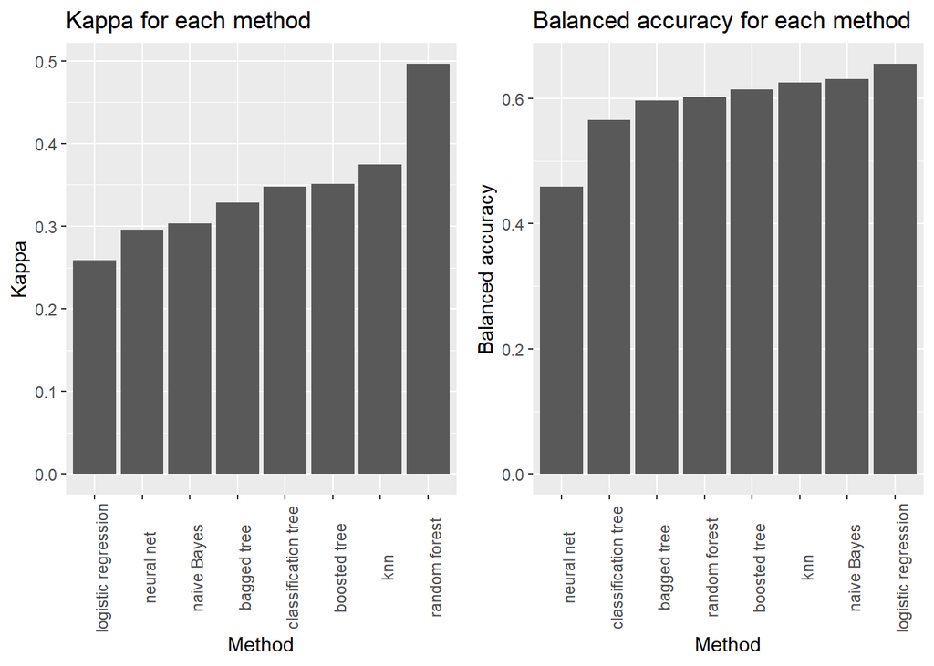

```r
all_kappa_plot = ggplot(data = results_df, aes(x = reorder(method, kappa))) +
  geom_bar(aes(y = kappa), stat = "identity") +
  labs(title = "Kappa for each method", x = "Method", y = "Kappa") +
  theme(axis.text.x = element_text(angle=90))

all_bal_acc_plot = ggplot(data = results_df, aes(x = reorder(method, balanced_accuracy))) +
  geom_bar(aes(y = balanced_accuracy), stat = "identity") +
  labs(title = "Balanced accuracy for each method", x = "Method", y = "Balanced accuracy") +
  theme(axis.text.x = element_text(angle=90))

plot_grid(all_kappa_plot, all_bal_acc_plot)
```

### Ensembles

```r
ensemble_prob_low_df = data.frame("knn_prob_low" = attr(best_knn_pred, "prob")[,3],
                     "log_prob_low" = os_log_prob[,3],
                     "nb_prob_low" = os_nb_prob[,3],
                     "tree_prob_low" = pruned_tree1_prob_test[,3],
                     "boosting_prob_low" = boost1_prob_test$prob[,3],
                     "bagging_prob_low" = bag1_prob_test$prob[,3],
                     "rf_prob_low" = rf1_prob_test[,3],
                     "nnet_prob_low" = test_pred_nn1[,3])
ensemble_prob_low_df$mean_prob_low = apply(ensemble_prob_low_df[,c(1,2,5,7)], 1, mean)
head(ensemble_prob_low_df)
```

```
##    knn_prob_low log_prob_low nb_prob_low tree_prob_low boosting_prob_low
## 2             0   0.77309686  0.13981175      0.000000        0.29894777
## 8             0   0.21146901  0.00792725      0.000000        0.13121962
## 10            0   0.22419847  0.02801932      0.000000        0.04075472
## 16            0   0.04869837  0.00276073      0.000000        0.00000000
## 21            0   0.42845514  0.14712599      0.000000        0.05555899
## 24            1   0.90074622  0.81086084      0.952381        0.64561551
##    bagging_prob_low rf_prob_low nnet_prob_low mean_prob_low
## 2              0.55       0.100   0.088932689    0.29301116
## 8              0.00       0.014   0.004140789    0.08917216
## 10             0.00       0.056   0.020970957    0.08023830
## 16             0.00       0.000   0.011903364    0.01217459
## 21             0.00       0.002   0.057560142    0.12150353
## 24             0.44       0.596   0.579583604    0.78559043
```

```r
ensemble_prob_inter_df = data.frame("knn_prob_inter" = attr(best_knn_pred, "prob")[,2],
                     "log_prob_inter" = os_log_prob[,2],
                     "nb_prob_inter" = os_nb_prob[,2],
                     "tree_prob_inter" = pruned_tree1_prob_test[,2],
                     "boosting_prob_inter" = boost1_prob_test$prob[,2],
                     "bagging_prob_inter" = bag1_prob_test$prob[,2],
                     "rf_prob_inter" = rf1_prob_test[,2],
                     "nnet_prob_inter" = test_pred_nn1[,2])
ensemble_prob_inter_df$mean_prob_inter = apply(ensemble_prob_inter_df[,c(1,2,5,7)], 1, mean)
head(ensemble_prob_inter_df)
```

```
##    knn_prob_inter log_prob_inter nb_prob_inter tree_prob_inter
## 2               1     0.20335112    0.68476606      1.00000000
## 8               1     0.66187915    0.92371260      1.00000000
## 10              1     0.40644241    0.55929249      1.00000000
## 16              0     0.25746639    0.11256673      0.86666667
## 21              0     0.29900199    0.05309515      0.00000000
## 24              0     0.09574893    0.18696631      0.04761905
##    boosting_prob_inter bagging_prob_inter rf_prob_inter nnet_prob_inter
## 2            0.6878942               0.45         0.878       0.9445283
## 8            0.6524447               1.00         0.808       0.8849977
## 10           0.4689815               0.00         0.594       0.7708970
## 16           0.3737503               0.00         0.430       0.4913243
## 21           0.2888439               0.00         0.072       0.5156588
## 24           0.3470573               0.56         0.396       0.6006858
##    mean_prob_inter
## 2        0.6923113
## 8        0.7805810
## 10       0.6173560
## 16       0.2653042
## 21       0.1649615
## 24       0.2097016
```

```r
ensemble_prob_high_df = data.frame("knn_prob_high" = attr(best_knn_pred, "prob")[,1],
                     "log_prob_high" = os_log_prob[,1],
                     "nb_prob_high" = os_nb_prob[,1],
                     "tree_prob_high" = pruned_tree1_prob_test[,1],
                     "boosting_prob_high" = boost1_prob_test$prob[,1],
                     "bagging_prob_high" = bag1_prob_test$prob[,1],
                     "rf_prob_high" = rf1_prob_test[,1],
                     "nnet_prob_high" = test_pred_nn1[,1])
ensemble_prob_high_df$mean_prob_high = apply(ensemble_prob_high_df[,c(1,2,5,7)], 1, mean)
head(ensemble_prob_high_df)
```

```
##    knn_prob_high log_prob_high nb_prob_high tree_prob_high boosting_prob_high
## 2              0   0.023552014  0.175422185      0.0000000        0.013158039
## 8              0   0.126651841  0.068360150      0.0000000        0.216335678
## 10             0   0.369359126  0.412688190      0.0000000        0.490263760
## 16             1   0.693835240  0.884672538      0.1333333        0.626249668
## 21             1   0.272542870  0.799778864      1.0000000        0.655597113
## 24             0   0.003504844  0.002172852      0.0000000        0.007327199
##    bagging_prob_high rf_prob_high nnet_prob_high mean_prob_high
## 2                  0        0.022     0.02481099    0.014677513
## 8                  0        0.178     0.10927765    0.130246880
## 10                 1        0.350     0.17698168    0.302405721
## 16                 1        0.570     0.49258641    0.722521227
## 21                 1        0.926     0.39455833    0.713534996
## 24                 0        0.008     0.05135879    0.004708011
```

```r
ensemble_prob_df = data.frame("Low" = ensemble_prob_low_df$mean_prob_low,
                              "Intermediate" = ensemble_prob_inter_df$mean_prob_inter,
                              "High" = ensemble_prob_high_df$mean_prob_high)
ensemble_prob_df$mean_prob_pred = as.factor(colnames(ensemble_prob_df)[apply(ensemble_prob_df,1,which.max)])
head(ensemble_prob_df)
```

```
##          Low Intermediate        High mean_prob_pred
## 1 0.29301116    0.6923113 0.014677513   Intermediate
## 2 0.08917216    0.7805810 0.130246880   Intermediate
## 3 0.08023830    0.6173560 0.302405721   Intermediate
## 4 0.01217459    0.2653042 0.722521227           High
## 5 0.12150353    0.1649615 0.713534996           High
## 6 0.78559043    0.2097016 0.004708011            Low
```

```r
ensembles_pred_df = data.frame("actual_value" = test_df$binned_quality,
                              "knn_pred" = best_knn_pred,
                              "log_pred" = os_log_pred$pred,
                              "nb_pred" = os_nb_pred,
                              "tree_pred" = pruned_tree1_pred_test,
                              "boosting_pred" = as.factor(boost1_pred_test$class),
                              "bagging_pred" = as.factor(bag1_pred_test$class),
                              "rf_pred" = rf1_pred_test,
                              "nnet_pred" = as.factor(test_pred_nn1$Prediction))
ensembles_pred_df$majority_vote_pred = as.factor(apply(ensembles_pred_df[,c(2,3,4,6,8)], 1, function(x) names(which.max(table(x)))))
ensembles_pred_df$mean_prob_pred = ensemble_prob_df$mean_prob_pred
head(ensembles_pred_df)
```

```
##    actual_value     knn_pred     log_pred      nb_pred    tree_pred
## 2  Intermediate Intermediate          Low Intermediate Intermediate
## 8  Intermediate Intermediate Intermediate Intermediate Intermediate
## 10 Intermediate Intermediate Intermediate Intermediate Intermediate
## 16         High         High         High         High Intermediate
## 21         High         High          Low         High         High
## 24 Intermediate          Low          Low          Low          Low
##    boosting_pred bagging_pred      rf_pred    nnet_pred majority_vote_pred
## 2   Intermediate          Low Intermediate Intermediate       Intermediate
## 8   Intermediate Intermediate Intermediate Intermediate       Intermediate
## 10          High         High Intermediate Intermediate       Intermediate
## 16          High         High         High         High               High
## 21          High         High         High Intermediate               High
## 24           Low Intermediate          Low Intermediate                Low
##    mean_prob_pred
## 2    Intermediate
## 8    Intermediate
## 10   Intermediate
## 16           High
## 21           High
## 24            Low
```

```r
majority_vote_cm <- confusionMatrix(ensembles_pred_df$majority_vote_pred, test_df[,11])
majority_vote_cm
```

```
## Confusion Matrix and Statistics
##
##               Reference
## Prediction     High Intermediate Low
##   High          170          166   2
##   Intermediate   39          520  16
##   Low             3           44  18
##
## Overall Statistics
##
##                Accuracy : 0.7239
##                  95% CI : (0.6948, 0.7517)
##     No Information Rate : 0.7464
##     P-Value [Acc > NIR] : 0.9499
##
##                   Kappa : 0.4294
##
##  Mcnemar's Test P-Value : <2e-16
##
## Statistics by Class:
##
##                      Class: High Class: Intermediate Class: Low
## Sensitivity               0.8019              0.7123    0.50000
## Specificity               0.7807              0.7782    0.95011
## Pos Pred Value            0.5030              0.9043    0.27692
## Neg Pred Value            0.9344              0.4789    0.98028
## Prevalence                0.2168              0.7464    0.03681
## Detection Rate            0.1738              0.5317    0.01840
## Detection Prevalence      0.3456              0.5879    0.06646
## Balanced Accuracy         0.7913              0.7453    0.72505
```

```r
kappa_majority = majority_vote_cm$overall[2]
kappa_majority
```

```
##     Kappa
## 0.4293531
```

```r
low_sensitivity = majority_vote_cm$byClass[3,1]
intermediate_sensitivity = majority_vote_cm$byClass[2,1]
high_sensitivity = majority_vote_cm$byClass[1,1]

bal_acc_majority = (low_sensitivity + intermediate_sensitivity + high_sensitivity) / 3
bal_acc_majority
```

```
## [1] 0.6714052
```

```r
mean_prob_cm <- confusionMatrix(ensembles_pred_df$mean_prob_pred, test_df[,11])
mean_prob_cm
```

```
## Confusion Matrix and Statistics
##
##               Reference
## Prediction     High Intermediate Low
##   High          153          116   2
##   Intermediate   55          561  13
##   Low             4           53  21
##
## Overall Statistics
##
##                Accuracy : 0.7515
##                  95% CI : (0.7232, 0.7783)
##     No Information Rate : 0.7464
##     P-Value [Acc > NIR] : 0.3725
##
##                   Kappa : 0.4562
##
##  Mcnemar's Test P-Value : 4.087e-10
##
## Statistics by Class:
##
##                      Class: High Class: Intermediate Class: Low
## Sensitivity               0.7217              0.7685    0.58333
## Specificity               0.8460              0.7258    0.93949
## Pos Pred Value            0.5646              0.8919    0.26923
## Neg Pred Value            0.9165              0.5158    0.98333
## Prevalence                0.2168              0.7464    0.03681
## Detection Rate            0.1564              0.5736    0.02147
## Detection Prevalence      0.2771              0.6431    0.07975
## Balanced Accuracy         0.7838              0.7471    0.76141
```

```r
kappa_mean_prob = mean_prob_cm$overall[2]
kappa_mean_prob
```

```
##     Kappa
## 0.4562365
```

```r
low_sensitivity = mean_prob_cm$byClass[3,1]
intermediate_sensitivity = mean_prob_cm$byClass[2,1]
high_sensitivity = mean_prob_cm$byClass[1,1]

bal_acc_mean_prob = (low_sensitivity + intermediate_sensitivity + high_sensitivity) / 3
bal_acc_mean_prob
```

```
## [1] 0.6911749
```

### Comparing results (including Ensembles)

```r
results_df[9,] = list("majority vote", kappa_majority, bal_acc_majority)
results_df[10,] = list("mean probability", kappa_mean_prob, bal_acc_mean_prob)
```

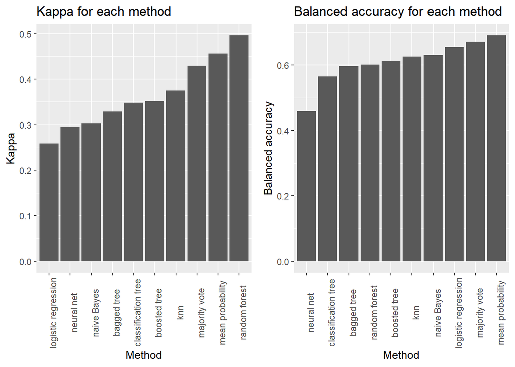

```r
all_kappa_plot2 = ggplot(data = results_df, aes(x = reorder(method, kappa))) +
  geom_bar(aes(y = kappa), stat = "identity") +
  labs(title = "Kappa for each method", x = "Method", y = "Kappa") +
  theme(axis.text.x = element_text(angle=90))

all_bal_acc_plot2 = ggplot(data = results_df, aes(x = reorder(method, balanced_accuracy))) +
  geom_bar(aes(y = balanced_accuracy), stat = "identity") +
  labs(title = "Balanced accuracy for each method", x = "Method", y = "Balanced accuracy") +
  theme(axis.text.x = element_text(angle=90))

plot_grid(all_kappa_plot2, all_bal_acc_plot2)
```

### Visualising Confusion Matrices for each method

We first create the data-frames associated to the confusion matrices of each method:

```r
plot_knn_cm <- as.data.frame(best_knn_cm$table)
plot_knn_cm$Prediction <- factor(plot_knn_cm$Prediction, levels=rev(levels(plot_knn_cm$Prediction)))
plot_knn_cm <- plot_knn_cm %>%
  mutate(pred = ifelse(plot_knn_cm$Prediction == plot_knn_cm$Reference, "correct", "error")) %>%
  group_by(Reference) %>%
  mutate(prop = Freq/sum(Freq))


plot_os_log_cm <- as.data.frame(os_log_cm$table)
plot_os_log_cm$Prediction <- factor(plot_os_log_cm$Prediction, levels=rev(levels(plot_os_log_cm$Prediction)))
plot_os_log_cm <- plot_os_log_cm %>%
  mutate(pred = ifelse(plot_os_log_cm$Prediction == plot_os_log_cm$Reference, "correct", "error")) %>%
  group_by(Reference) %>%
  mutate(prop = Freq/sum(Freq))

plot_bayes_cm <- as.data.frame(bayes_cm$table)
plot_bayes_cm$Prediction <- factor(plot_bayes_cm$Prediction, levels=rev(levels(plot_bayes_cm$Prediction)))
plot_bayes_cm <- plot_bayes_cm %>%
  mutate(pred = ifelse(plot_bayes_cm$Prediction == plot_bayes_cm$Reference, "correct", "error")) %>%
  group_by(Reference) %>%
  mutate(prop = Freq/sum(Freq))

plot_pruned_tree1_cm <- as.data.frame(pruned_tree1_cm$table)
plot_pruned_tree1_cm$Prediction <- factor(plot_pruned_tree1_cm$Prediction, levels=rev(levels(plot_pruned_tree1_cm$Prediction)))
plot_pruned_tree1_cm <- plot_pruned_tree1_cm %>%
  mutate(pred = ifelse(plot_pruned_tree1_cm$Prediction == plot_pruned_tree1_cm$Reference, "correct", "error")) %>%
  group_by(Reference) %>%
  mutate(prop = Freq/sum(Freq))

plot_boost1_cm <- as.data.frame(boost1_cm$table)
plot_boost1_cm$Prediction <- factor(plot_boost1_cm$Prediction, levels=rev(levels(plot_boost1_cm$Prediction)))
plot_boost1_cm <- plot_boost1_cm %>%
  mutate(pred = ifelse(plot_boost1_cm$Prediction == plot_boost1_cm$Reference, "correct", "error")) %>%
  group_by(Reference) %>%
  mutate(prop = Freq/sum(Freq))

plot_bag1_cm <- as.data.frame(bag1_cm$table)
plot_bag1_cm$Prediction <- factor(plot_bag1_cm$Prediction, levels=rev(levels(plot_bag1_cm$Prediction)))
plot_bag1_cm <- plot_bag1_cm %>%
  mutate(pred = ifelse(plot_bag1_cm$Prediction == plot_bag1_cm$Reference, "correct", "error")) %>%
  group_by(Reference) %>%
  mutate(prop = Freq/sum(Freq))

plot_rf1_cm <- as.data.frame(rf1_cm$table)
plot_rf1_cm$Prediction <- factor(plot_rf1_cm$Prediction, levels=rev(levels(plot_rf1_cm$Prediction)))
plot_rf1_cm <- plot_rf1_cm %>%
  mutate(pred = ifelse(plot_rf1_cm$Prediction == plot_rf1_cm$Reference, "correct", "error")) %>%
  group_by(Reference) %>%
  mutate(prop = Freq/sum(Freq))

plot_nn1_cm <- as.data.frame(nn1_cm$table)
plot_nn1_cm$Prediction <- factor(plot_nn1_cm$Prediction, levels=rev(levels(plot_nn1_cm$Prediction)))
plot_nn1_cm <- plot_nn1_cm %>%
  mutate(pred = ifelse(plot_nn1_cm$Prediction == plot_nn1_cm$Reference, "correct", "error")) %>%
  group_by(Reference) %>%
  mutate(prop = Freq/sum(Freq))

plot_majority_vote_cm <- as.data.frame(majority_vote_cm$table)
plot_majority_vote_cm$Prediction <- factor(plot_majority_vote_cm$Prediction, levels=rev(levels(plot_majority_vote_cm$Prediction)))
plot_majority_vote_cm <- plot_majority_vote_cm %>%
  mutate(pred = ifelse(plot_majority_vote_cm$Prediction == plot_majority_vote_cm$Reference, "correct", "error")) %>%
  group_by(Reference) %>%
  mutate(prop = Freq/sum(Freq))

plot_mean_prob_cm <- as.data.frame(mean_prob_cm$table)
plot_mean_prob_cm$Prediction <- factor(plot_mean_prob_cm$Prediction, levels=rev(levels(plot_mean_prob_cm$Prediction)))
plot_mean_prob_cm <- plot_mean_prob_cm %>%
  mutate(pred = ifelse(plot_mean_prob_cm$Prediction == plot_mean_prob_cm$Reference, "correct", "error")) %>%
  group_by(Reference) %>%
  mutate(prop = Freq/sum(Freq))
```

Let’s create the plots:

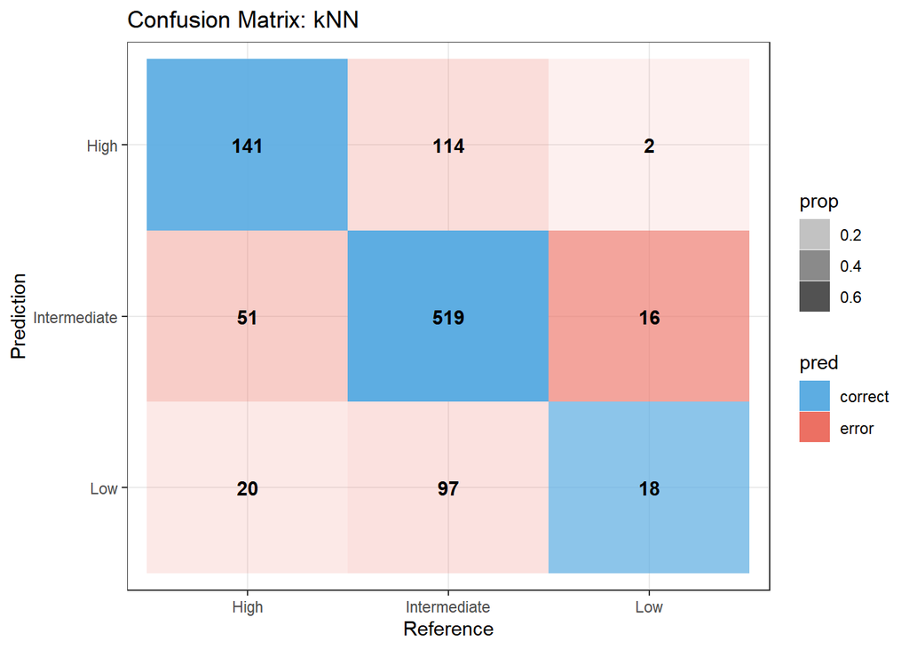

```r
plot_knn_cm <- ggplot(plot_knn_cm, aes(Reference, Prediction, fill = pred, alpha = prop)) +
        geom_tile() +
        theme_bw() +
        geom_text(aes(label=Freq), vjust = .5, fontface  = "bold", alpha = 1) +
        scale_fill_manual(values = c(correct = "#5DADE2", error = "#EC7063")) +
        xlim((levels(plot_knn_cm$Reference))) +
        labs(x = "Reference",y = "Prediction", title = "Confusion Matrix: kNN")
plot_knn_cm
```

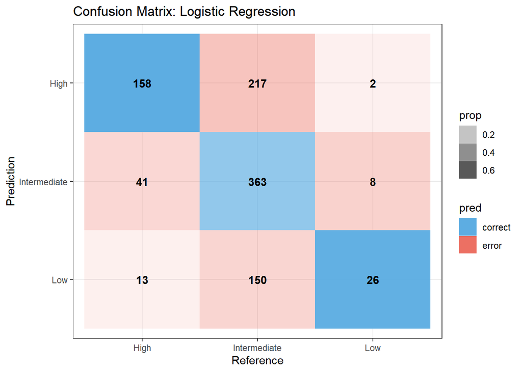

```r
plot_os_log_cm <- ggplot(plot_os_log_cm, aes(Reference, Prediction, fill = pred, alpha = prop)) +
    geom_tile() +
    theme_bw() +
    geom_text(aes(label=Freq), vjust = .5, fontface  = "bold", alpha = 1) +
    scale_fill_manual(values = c(correct = "#5DADE2", error = "#EC7063")) +
    xlim((levels(plot_os_log_cm$Reference))) +
    labs(x = "Reference",y = "Prediction", title = "Confusion Matrix: Logistic Regression")
plot_os_log_cm
```

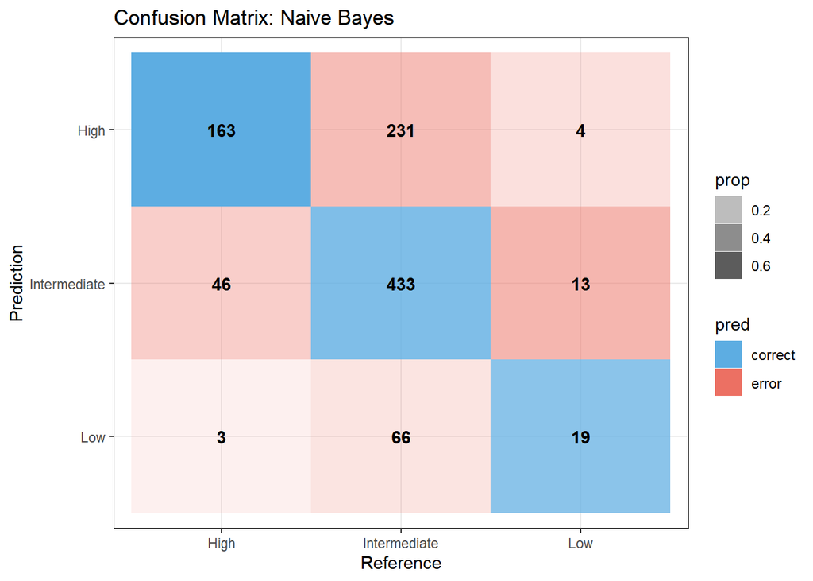

```r
plot_bayes_cm <- ggplot(plot_bayes_cm, aes(Reference, Prediction, fill = pred, alpha = prop)) +
    geom_tile() +
    theme_bw() +
    geom_text(aes(label=Freq), vjust = .5, fontface  = "bold", alpha = 1) +
    scale_fill_manual(values = c(correct = "#5DADE2", error = "#EC7063")) +
    xlim((levels(plot_bayes_cm$Reference))) +
    labs(x = "Reference",y = "Prediction", title = "Confusion Matrix: Naive Bayes")
plot_bayes_cm
```

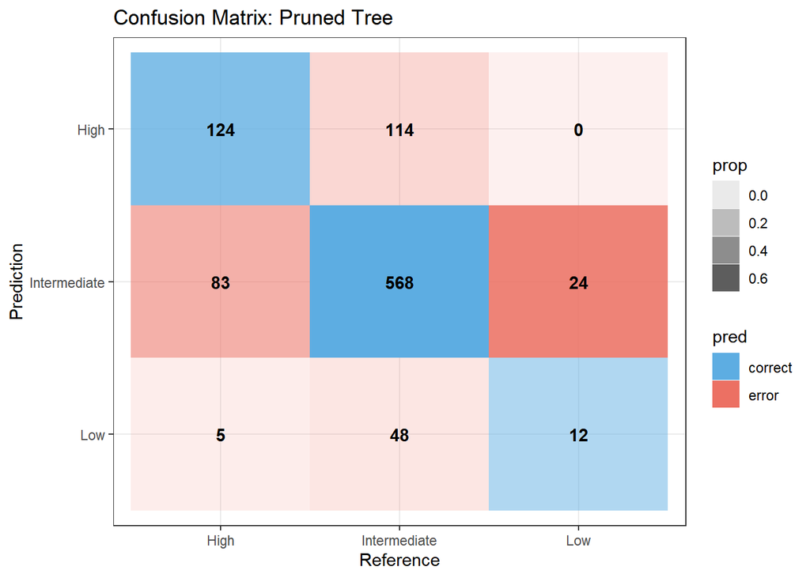

```r
plot_pruned_tree1_cm <- ggplot(plot_pruned_tree1_cm, aes(Reference, Prediction, fill = pred, alpha = prop)) +
    geom_tile() +
    theme_bw() +
    geom_text(aes(label=Freq), vjust = .5, fontface  = "bold", alpha = 1) +
    scale_fill_manual(values = c(correct = "#5DADE2", error = "#EC7063")) +
    xlim((levels(plot_pruned_tree1_cm$Reference))) +
    labs(x = "Reference",y = "Prediction", title = "Confusion Matrix: Pruned Tree")
plot_pruned_tree1_cm
```

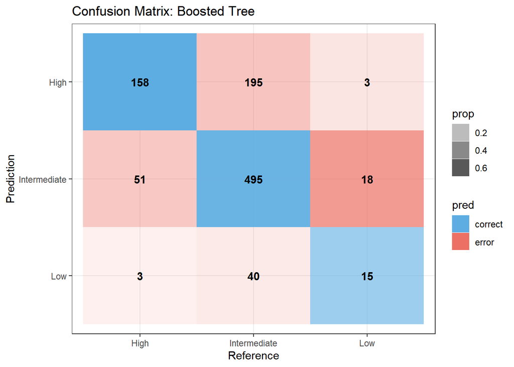

```r
plot_boost1_cm <- ggplot(plot_boost1_cm, aes(Reference, Prediction, fill = pred, alpha = prop)) +
    geom_tile() +
    theme_bw() +
    geom_text(aes(label=Freq), vjust = .5, fontface  = "bold", alpha = 1) +
    scale_fill_manual(values = c(correct = "#5DADE2", error = "#EC7063")) +
    xlim((levels(plot_boost1_cm$Reference))) +
    labs(x = "Reference",y = "Prediction", title = "Confusion Matrix: Boosted Tree")
plot_boost1_cm
```

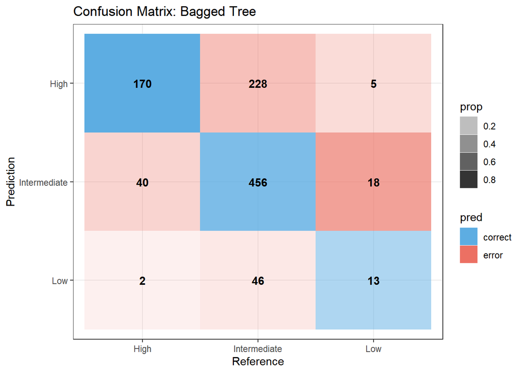

```r
plot_bag1_cm <- ggplot(plot_bag1_cm, aes(Reference, Prediction, fill = pred, alpha = prop)) +
    geom_tile() +
    theme_bw() +
    geom_text(aes(label=Freq), vjust = .5, fontface  = "bold", alpha = 1) +
    scale_fill_manual(values = c(correct = "#5DADE2", error = "#EC7063")) +
    xlim((levels(plot_bag1_cm$Reference))) +
    labs(x = "Reference",y = "Prediction", title = "Confusion Matrix: Bagged Tree")
plot_bag1_cm
```

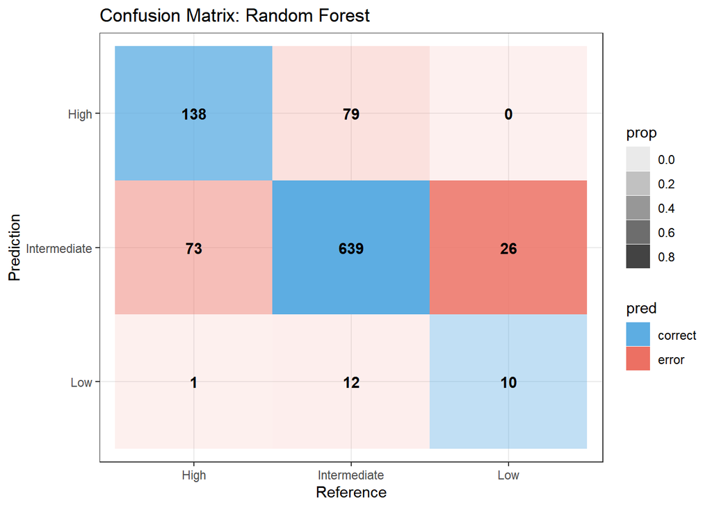

```r
plot_rf1_cm <- ggplot(plot_rf1_cm, aes(Reference, Prediction, fill = pred, alpha = prop)) +
    geom_tile() +
    theme_bw() +
    geom_text(aes(label=Freq), vjust = .5, fontface  = "bold", alpha = 1) +
    scale_fill_manual(values = c(correct = "#5DADE2", error = "#EC7063")) +
    xlim((levels(plot_rf1_cm$Reference))) +
    labs(x = "Reference",y = "Prediction", title = "Confusion Matrix: Random Forest")
plot_rf1_cm
```

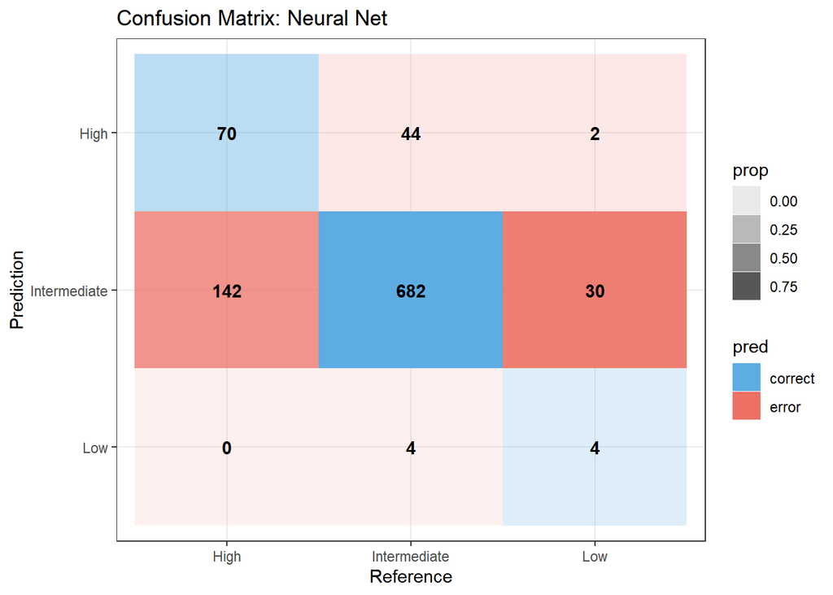

```r
plot_nn1_cm <- ggplot(plot_nn1_cm, aes(Reference, Prediction, fill = pred, alpha = prop)) +
    geom_tile() +
    theme_bw() +
    geom_text(aes(label=Freq), vjust = .5, fontface  = "bold", alpha = 1) +
    scale_fill_manual(values = c(correct = "#5DADE2", error = "#EC7063")) +
    xlim((levels(plot_nn1_cm$Reference))) +
    labs(x = "Reference",y = "Prediction", title = "Confusion Matrix: Neural Net")
plot_nn1_cm
```

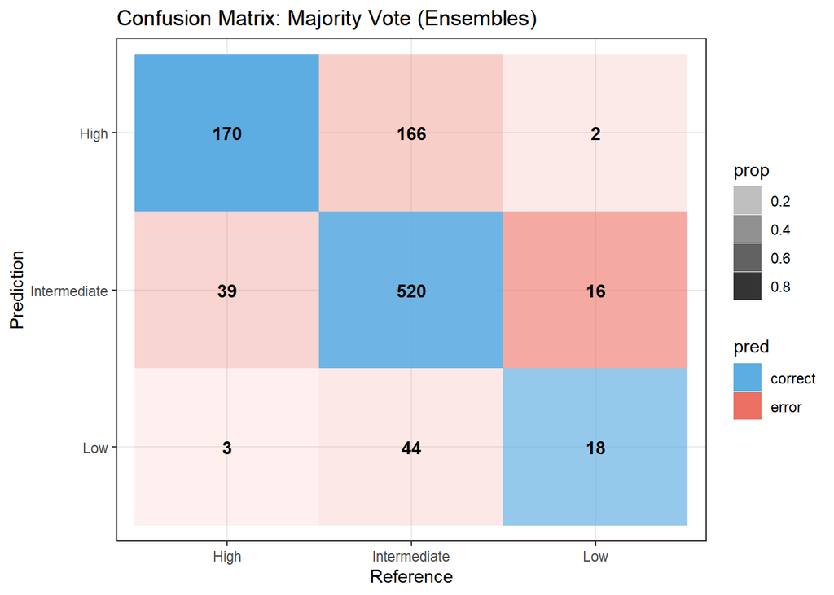

```r
plot_majority_vote_cm <- ggplot(plot_majority_vote_cm, aes(Reference, Prediction, fill = pred, alpha = prop)) +
    geom_tile() +
    theme_bw() +
    geom_text(aes(label=Freq), vjust = .5, fontface  = "bold", alpha = 1) +
    scale_fill_manual(values = c(correct = "#5DADE2", error = "#EC7063")) +
    xlim((levels(plot_majority_vote_cm$Reference))) +
    labs(x = "Reference",y = "Prediction", title = "Confusion Matrix: Majority Vote (Ensembles)")
plot_majority_vote_cm
```

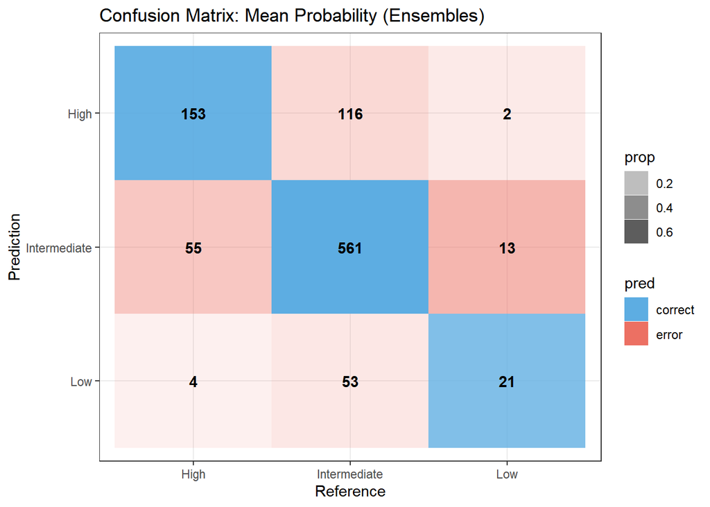

```r
plot_mean_prob_cm <- ggplot(plot_mean_prob_cm, aes(Reference, Prediction, fill = pred, alpha = prop)) +
    geom_tile() +
    theme_bw() +
    geom_text(aes(label=Freq), vjust = .5, fontface  = "bold", alpha = 1) +
    scale_fill_manual(values = c(correct = "#5DADE2", error = "#EC7063")) +
    xlim((levels(plot_mean_prob_cm$Reference))) +
    labs(x = "Reference",y = "Prediction", title = "Confusion Matrix: Mean Probability (Ensembles)")
plot_mean_prob_cm
```